# Non-Linear Models

Real relationships are seldom linear. However, in the absence of strong theory for a specific functional relationship, relationships are assumed to be linear. Linear models are parsimonious and linear relationships are easy to interpret. When the linearity assumption is not good enough, we can turn to non-linear models such as

- polynomials
- splines
- generalized additive models

… which offer a lot of flexibility without losing the ease and interpretability of linear models

### Strengths

- Flexible
- Often better at prediction than linear models
- Useful when prior research suggets a non-linear relationship

### Weaknesses

- Can overfit the data
- Harder to interpret than linear models
- Depending on complexity, may be computationally expensive

## Overview

This note will demonstrate the use of non-linear models to estimate earnings based on characteristics of individuals. The note will examine polynomial regression, splines and general additive models.

## Data Description

Earning data is derived from a survey of individuals on a multitude of characteristics including demographics, physical characteristics, health, well-being and earning. (Original Data Source: Regression and Other stories, by Andrew Gelman, Jennifer Hill, and Avi Vekhtari). We are interested in examining the factors that influence annual earning (`earn`) and predicting an individuals annual earning.

Data consists of characteristics of a set of employees and their annual earning. Variables included are:

- earn: Annual earning in dollars
- age: Age in years
- gender: male, female
- height: Height in inches
- weight: Weight in pounds
- ethnicity: White, African American, Hispanic, Asian
- education: Years of education
- walk: Frequency of taking a walk (in a week)
- exercise: Frequency of strenuous exercise (in a week)
- smokenow: Smoke seven or more cigarettes a week (1 = Yes, 2 = No)
- tense: Days felt tense or anxious

## Read Data

```python
import pandas as pd
import numpy as np
import matplotlib.pyplot as plt
```

```python
data = pd.read_csv('earning.csv')
```

## Data Partition

Evaluating a model using data to estimate it risks overfitting the model to the data used to build it. For this reason, it is best to evaluate the model using a different dataset. Since getting a fresh dataset for evaluating a model may be costly, time consuming and in some cases impossible, it is common to split the data into a train and test sample, estimating the model using the train and evaluating it using the test.

Let us start by splitting the data into a train and test sample such that 70% of the data is in the train sample.

```python
train = data.sample(frac = 0.7,random_state=1031)
test = data.drop(labels = train.index)
```

## Explore Data

```python
train.info()
```

```
<class 'pandas.core.frame.DataFrame'>
Index: 1250 entries, 1042 to 1692
Data columns (total 11 columns):
 #   Column     Non-Null Count  Dtype
---  ------     --------------  -----
 0   earn       1250 non-null   int64
 1   age        1250 non-null   int64
 2   gender     1250 non-null   object
 3   height     1250 non-null   int64
 4   weight     1250 non-null   int64
 5   ethnicity  1250 non-null   object
 6   education  1250 non-null   int64
 7   walk       1250 non-null   int64
 8   exercise   1250 non-null   int64
 9   smokenow   1250 non-null   int64
 10  tense      1250 non-null   int64
dtypes: int64(9), object(2)
memory usage: 117.2+ KB
```

```python
train.head()
```

|  | earn | age | gender | height | weight | ethnicity | education | walk | exercise | smokenow | tense |
| --- | --- | --- | --- | --- | --- | --- | --- | --- | --- | --- | --- |
| 1042 | 27960 | 24 | male | 73 | 165 | White | 12 | 7 | 7 | 2 | 1 |
| 886 | 104850 | 43 | female | 66 | 151 | White | 16 | 5 | 2 | 2 | 0 |
| 1039 | 39610 | 38 | female | 64 | 125 | White | 12 | 8 | 2 | 2 | 1 |
| 1239 | 34950 | 81 | female | 66 | 140 | White | 12 | 1 | 1 | 2 | 0 |
| 437 | 46600 | 42 | male | 74 | 195 | White | 12 | 8 | 2 | 2 | 7 |

```python
train.describe(include = 'all')
```

|  | earn | age | gender | height | weight | ethnicity | education | walk | exercise | smokenow | tense |
| --- | --- | --- | --- | --- | --- | --- | --- | --- | --- | --- | --- |
| count | 1250.000000 | 1250.000000 | 1250 | 1250.000000 | 1250.000000 | 1250 | 1250.000000 | 1250.000000 | 1250.000000 | 1250.000000 | 1250.000000 |
| unique | NaN | NaN | 2 | NaN | NaN | 4 | NaN | NaN | NaN | NaN | NaN |
| top | NaN | NaN | female | NaN | NaN | White | NaN | NaN | NaN | NaN | NaN |
| freq | NaN | NaN | 780 | NaN | NaN | 1037 | NaN | NaN | NaN | NaN | NaN |
| mean | 48135.236800 | 43.014400 | NaN | 66.636800 | 157.166400 | NaN | 13.206400 | 5.328800 | 3.076800 | 1.746400 | 1.351200 |
| std | 52437.529906 | 17.078487 | NaN | 3.860571 | 34.410481 | NaN | 2.596843 | 2.573167 | 2.320002 | 0.435245 | 2.097469 |
| min | 0.000000 | 18.000000 | NaN | 57.000000 | 85.000000 | NaN | 2.000000 | 1.000000 | 1.000000 | 1.000000 | 0.000000 |
| 25% | 13980.000000 | 29.000000 | NaN | 64.000000 | 130.000000 | NaN | 12.000000 | 3.000000 | 1.000000 | 1.000000 | 0.000000 |
| 50% | 34950.000000 | 39.500000 | NaN | 66.000000 | 150.000000 | NaN | 12.000000 | 6.000000 | 2.000000 | 2.000000 | 0.000000 |
| 75% | 62910.000000 | 55.000000 | NaN | 70.000000 | 180.000000 | NaN | 15.000000 | 8.000000 | 5.000000 | 2.000000 | 2.000000 |
| max | 932000.000000 | 91.000000 | NaN | 82.000000 | 312.000000 | NaN | 18.000000 | 8.000000 | 7.000000 | 2.000000 | 7.000000 |

## Simple Regression: age

As people get older, they gain experience and get better at doing their job. Therefore, it is reasonable to expect age to be positively related to earn. We can visualize this using a scatterplot. Is there a discernible trend ?

```python
import matplotlib.pyplot as plt
```

```python
train
```

|  | earn | age | gender | height | weight | ethnicity | education | walk | exercise | smokenow | tense |
| --- | --- | --- | --- | --- | --- | --- | --- | --- | --- | --- | --- |
| 1042 | 27960 | 24 | male | 73 | 165 | White | 12 | 7 | 7 | 2 | 1 |
| 886 | 104850 | 43 | female | 66 | 151 | White | 16 | 5 | 2 | 2 | 0 |
| 1039 | 39610 | 38 | female | 64 | 125 | White | 12 | 8 | 2 | 2 | 1 |
| 1239 | 34950 | 81 | female | 66 | 140 | White | 12 | 1 | 1 | 2 | 0 |
| 437 | 46600 | 42 | male | 74 | 195 | White | 12 | 8 | 2 | 2 | 7 |
| ... | ... | ... | ... | ... | ... | ... | ... | ... | ... | ... | ... |
| 298 | 74560 | 35 | female | 66 | 112 | Asian | 18 | 5 | 2 | 2 | 0 |
| 948 | 23300 | 31 | male | 72 | 150 | White | 11 | 7 | 5 | 1 | 0 |
| 420 | 33785 | 55 | female | 64 | 150 | White | 12 | 7 | 1 | 2 | 0 |
| 326 | 93200 | 44 | female | 64 | 135 | White | 13 | 8 | 2 | 1 | 0 |
| 1692 | 69900 | 28 | female | 64 | 140 | White | 17 | 4 | 6 | 2 | 0 |

1250 rows × 11 columns

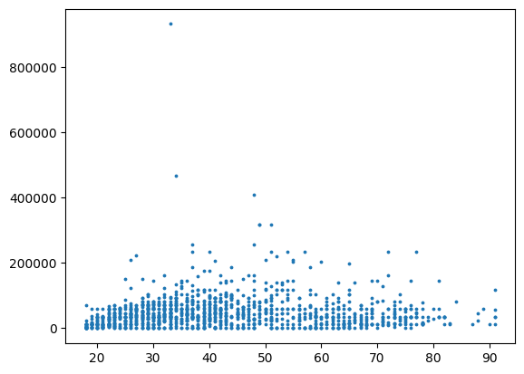

```python
#train.plot(x = 'age', y = 'earn', kind = 'scatter', s=3)
plt.scatter(train.age, train.earn, s = 3)
plt.show()
```

```python
from statsmodels.formula.api import ols
reg = ols('earn~age', data = train)
reg = reg.fit()
pred_reg = reg.predict()
rmse_reg = np.sqrt(np.mean(np.square(pred_reg - train.earn)))
```

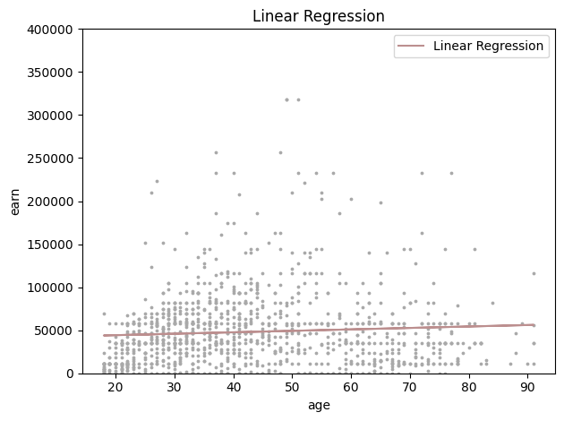

```python
plt.scatter(train.age, train.earn, s = 3, color = 'darkgrey')
plt.plot(train.age, pred_reg,  label='Linear Regression',color = 'rosybrown')
plt.xlabel('age')
plt.ylabel('earn')
plt.ylim(0,4e5)
plt.title('Linear Regression')
plt.legend()
plt.tight_layout()
plt.show()
```

## Polynomial Regression (Degree 2)

The relationship between age and earn may non-linear. As people get older they earn more because they get better at the job. Beyond a certain age, people may decide to take it easy, dialing back responsibilities or switching to working part time. Such a change may be reflected in lower earn. To explore this possibility, let us fit a quadratic function.

### Fit

```python
from statsmodels.formula.api import ols
polyreg_2 = ols('earn~age + I(age**2)', data = train)
polyreg_2 = polyreg_2.fit()
```

### Visualize

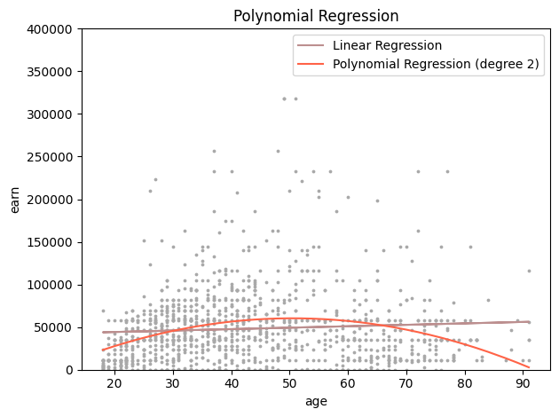

```python
pred_polyreg_2 = polyreg_2.predict(train.age)
sorted_index = np.argsort(train['age'])
age_sorted  = train['age'].iloc[sorted_index]
pred_polyreg_2_sorted = pd.Series(pred_polyreg_2).iloc[sorted_index]

plt.scatter(train.age, train.earn, s = 3, color = 'darkgray')
plt.plot(train.age, pred_reg,  label='Linear Regression',color = 'rosybrown')
plt.plot(age_sorted, pred_polyreg_2_sorted,  label='Polynomial Regression (degree 2)',color = 'tomato')
plt.xlabel('age')
plt.ylabel('earn')
plt.ylim(0,4e5)
plt.title('Polynomial Regression')
plt.legend()
plt.tight_layout()
plt.show()
```

### Inference

```python
polyreg_2.summary()
```

OLS Regression Results

| Dep. Variable: | earn | R-squared: | 0.044 |
| --- | --- | --- | --- |
| Model: | OLS | Adj. R-squared: | 0.043 |
| Method: | Least Squares | F-statistic: | 29.04 |
| Date: | Thu, 25 Sep 2025 | Prob (F-statistic): | 4.73e-13 |
| Time: | 18:47:48 | Log-Likelihood: | -15329. |
| No. Observations: | 1250 | AIC: | 3.066e+04 |
| Df Residuals: | 1247 | BIC: | 3.068e+04 |
| Df Model: | 2 |  |  |
| Covariance Type: | nonrobust |  |  |

|  | coef | std err | t | P>\|t\| | [0.025 | 0.975] |
| --- | --- | --- | --- | --- | --- | --- |
| Intercept | -2.923e+04 | 1.03e+04 | -2.835 | 0.005 | -4.95e+04 | -9003.746 |
| age | 3546.1645 | 466.834 | 7.596 | 0.000 | 2630.298 | 4462.032 |
| I(age ** 2) | -35.0993 | 4.770 | -7.359 | 0.000 | -44.457 | -25.742 |

| Omnibus: | 1486.302 | Durbin-Watson: | 2.047 |
| --- | --- | --- | --- |
| Prob(Omnibus): | 0.000 | Jarque-Bera (JB): | 313286.283 |
| Skew: | 5.753 | Prob(JB): | 0.00 |
| Kurtosis: | 79.699 | Cond. No. | 1.93e+04 |

Notes:  
[1] Standard Errors assume that the covariance matrix of the errors is correctly specified.  
[2] The condition number is large, 1.93e+04. This might indicate that there are  
strong multicollinearity or other numerical problems.

### Predict

```python
pred_polyreg_2 = polyreg_2.predict()
rmse_polyreg_2 = np.sqrt(np.mean(np.square(pred_polyreg_2 - train.earn)))
rmse_polyreg_2
```

```
np.float64(51237.10383996226)
```

## Polynomial Regression (Higher Degrees)

Use of higher degree polynomials are driven less by theory and more by a desire to fit the data.

### Fit

```python
from statsmodels.formula.api import ols
polyreg_3 = ols('earn~age + I(age**2) + I(age**3)', data = train)
polyreg_3 = polyreg_3.fit()
```

```python
polyreg_4 = ols('earn~age + I(age**2) + I(age**3) + I(age**4)', data = train)
polyreg_4 = polyreg_4.fit()
```

```python
polyreg_5 = ols('earn~age + I(age**2) + I(age**3) + I(age**4) + I(age**5)', data = train)
polyreg_5 = polyreg_5.fit()
```

### Visualize

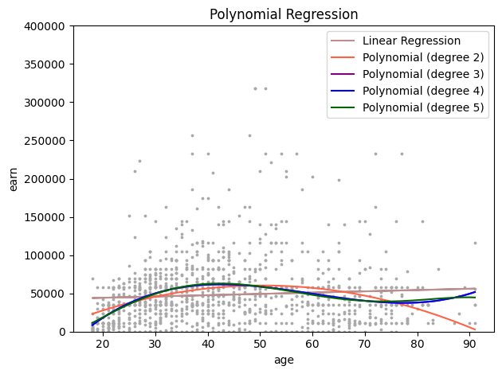

```python
sorted_index = np.argsort(train['age'])
age_sorted  = train['age'].iloc[sorted_index]
pred_polyreg_2 = polyreg_2.predict(train.age)
pred_polyreg_2_sorted = pd.Series(pred_polyreg_2).iloc[sorted_index]
pred_polyreg_3 = polyreg_3.predict(train.age)
pred_polyreg_3_sorted = pd.Series(pred_polyreg_3).iloc[sorted_index]
pred_polyreg_4 = polyreg_4.predict(train.age)
pred_polyreg_4_sorted = pd.Series(pred_polyreg_4).iloc[sorted_index]
pred_polyreg_5 = polyreg_5.predict(train.age)
pred_polyreg_5_sorted = pd.Series(pred_polyreg_5).iloc[sorted_index]

plt.scatter(train.age, train.earn, s = 3, color = 'darkgray')
plt.plot(train.age, pred_reg,  label='Linear Regression',color = 'rosybrown')
plt.plot(age_sorted, pred_polyreg_2_sorted,  label='Polynomial (degree 2)',color = 'tomato')
plt.plot(age_sorted, pred_polyreg_3_sorted,  label='Polynomial (degree 3)',color = 'purple')
plt.plot(age_sorted, pred_polyreg_4_sorted,  label='Polynomial (degree 4)',color = 'blue')
plt.plot(age_sorted, pred_polyreg_5_sorted,  label='Polynomial (degree 5)',color = 'darkgreen')
plt.xlabel('age')
plt.ylabel('earn')
plt.ylim(0,4e5)
plt.title('Polynomial Regression')
plt.legend()
plt.tight_layout()
plt.show()
```

### Model Comparison

#### Statistics

A regression without any polynomial functions is nested within a second degree regression model as the former can be derived from the latter by dropping a polynomial term. Nested models can be compared through an ANOVA test. Here, we compare each model with another that is a degree higher. A statistically significant difference would support use of the more complex model. Results indicate going with a Polynomial with Degree 3.

```python
from statsmodels.stats.anova import anova_lm

anova_lm(reg, polyreg_2,polyreg_3, polyreg_4, polyreg_5)\
.assign(model = ['Linear Regression','Polynomial Degree 2','Polynomial Degree 3','Polynomial Degree 4','Polynomial Degree 5'])\
.set_index('model')
```

| model | df_resid | ssr | df_diff | ss_diff | F | Pr(>F) |
| --- | --- | --- | --- | --- | --- | --- |
| Linear Regression | 1248.0 | 3.424050e+12 | 0.0 | NaN | NaN | NaN |
| Polynomial Degree 2 | 1247.0 | 3.281551e+12 | 1.0 | 1.424988e+11 | 55.073427 | 2.141588e-13 |
| Polynomial Degree 3 | 1246.0 | 3.220716e+12 | 1.0 | 6.083476e+10 | 23.511629 | 1.398144e-06 |
| Polynomial Degree 4 | 1245.0 | 3.220716e+12 | 1.0 | 2.810029e+05 | 0.000109 | 9.916868e-01 |
| Polynomial Degree 5 | 1244.0 | 3.218767e+12 | 1.0 | 1.949308e+09 | 0.753375 | 3.855771e-01 |

#### Performance

```python
rmse_reg = np.sqrt(np.mean(np.square(pred_reg - train.earn)))
rmse_polyreg_2 = np.sqrt(np.mean(np.square(pred_polyreg_2 - train.earn)))
rmse_polyreg_3 = np.sqrt(np.mean(np.square(pred_polyreg_3 - train.earn)))
rmse_polyreg_4 = np.sqrt(np.mean(np.square(pred_polyreg_4 - train.earn)))
rmse_polyreg_5 = np.sqrt(np.mean(np.square(pred_polyreg_5 - train.earn)))
rmse_table = pd.DataFrame({'Model': ['Linear Regression','Polynomial Degree 2','Polynomial Degree 3','Polynomial Degree 4','Polynomial Degree 5'],
                           'RMSE': [rmse_reg, rmse_polyreg_2, rmse_polyreg_3, rmse_polyreg_4, rmse_polyreg_5]})
rmse_table
```

|  | Model | RMSE |
| --- | --- | --- |
| 0 | Linear Regression | 52337.747862 |
| 1 | Polynomial Degree 2 | 51237.103840 |
| 2 | Polynomial Degree 3 | 50759.954678 |
| 3 | Polynomial Degree 4 | 50759.952464 |
| 4 | Polynomial Degree 5 | 50744.589148 |

## Polynomial Regression using Scikit-Learn

With a large number of features, manually transforming variables can be tedious. Scikit-learn framework makes it easier to construct polynomial features to be used in a model. However, it does not provide tests of statistical significance.

Let us begin by examining the case of second degree polynomial function of age.

## Polynomial Regression (Degree 2) with Scikit-Learn

We construct polynomial features from the train data before passing them to regression.

```python
from sklearn.linear_model import LinearRegression
from sklearn.preprocessing import PolynomialFeatures
polynomial_features = PolynomialFeatures(degree = 2, include_bias=True, interaction_only=False)
X_poly_train = polynomial_features.fit_transform(train.loc[:,['age']])
X_poly_train[0:5,:]
```

```
array([[1.000e+00, 2.400e+01, 5.760e+02],
       [1.000e+00, 4.300e+01, 1.849e+03],
       [1.000e+00, 3.800e+01, 1.444e+03],
       [1.000e+00, 8.100e+01, 6.561e+03],
       [1.000e+00, 4.200e+01, 1.764e+03]])
```

```python
reg = LinearRegression()
reg.fit(X_poly_train, train.earn)
reg.coef_
```

```
array([   0.        , 3546.16451332,  -35.09926122])
```

```python
pred_train = reg.predict(X_poly_train)
from sklearn.metrics import root_mean_squared_error
root_mean_squared_error(train.earn, pred_train)
```

```
51237.10383996226
```

## Polynomial Regression (Degree 3) with Scikit-Learn

Extending the model to Degree 3. Note the RMSE results here are the same as from statsmodels.

```python
from sklearn.linear_model import LinearRegression
from sklearn.preprocessing import PolynomialFeatures
polynomial_features = PolynomialFeatures(degree = 3, include_bias=True, interaction_only=False)
X_poly_train = polynomial_features.fit_transform(train.loc[:,['age']])
reg = LinearRegression()
reg.fit(X_poly_train, train.earn)
pred_train = reg.predict(X_poly_train)
from sklearn.metrics import root_mean_squared_error
root_mean_squared_error(train.earn, pred_train)
```

```
50759.95467802349
```

## Polynomial regression (Degree 3) using all Predictors

Next, we will extend the above model to all the predictors by including second and third degree polynomial terms. The function PolynomialFeatures() will automatically also construct all interaction terms. This will result in a large number of features which may improve fit. On the other hand, this model is not easily interpretable and risks overfitting the train data.

```python
from sklearn.preprocessing import PolynomialFeatures
polynomial_features = PolynomialFeatures(degree = 3, include_bias=True, interaction_only=False)
X_dummies = pd.get_dummies(train.drop(['earn'], axis = 1), columns = ['gender','ethnicity','smokenow'],drop_first=True)
polynomial_features.fit(X_dummies)
X_poly_train = polynomial_features.transform(X_dummies)
X_poly_train.shape
```

```
(1250, 455)
```

```python
reg = LinearRegression()
reg.fit(X_poly_train, train.earn)
pred_train = reg.predict(X_poly_train)
from sklearn.metrics import root_mean_squared_error
root_mean_squared_error(train.earn, pred_train)
```

```
39361.39773448793
```

```python
X_test_dummies = pd.get_dummies(test.drop(['earn'], axis = 1),
                                columns = ['gender','ethnicity','smokenow'], drop_first=True)
X_poly_test = polynomial_features.transform(X_test_dummies)

pred_test = reg.predict(X_poly_test)
from sklearn.metrics import root_mean_squared_error
root_mean_squared_error(test.earn, pred_test)
```

```
62016.37716652901
```

## Splines

- Polynomial functions fit the same function over the entire range of predictor variable
- Step functions segment the predictor and allow different functions to be fit to each section. However, such functions tend to be discontinuous at the knots.
- Splines ensure that the functions are continuous at the knots
- Linear Spline is a piecewise linear polynomial continuous at each knot
- A cubic spline is a piecewise cubic polynomial with continuous derivatives up to order 2 at each knot

### Linear Spline

```python
from sklearn.preprocessing import SplineTransformer
from sklearn.linear_model import LinearRegression
X_train = train.loc[:,['age']]  # to generate a dataframe. train.age will create a pandas series
y_train = train.earn
linear_spline = SplineTransformer(degree =1,  n_knots = 4, include_bias=False)
X_train = linear_spline.fit_transform(X_train)
reg_linear_spline = LinearRegression()
reg_linear_spline.fit(X_train, y_train)
pred_linear_spline = reg_linear_spline.predict(X_train)
```

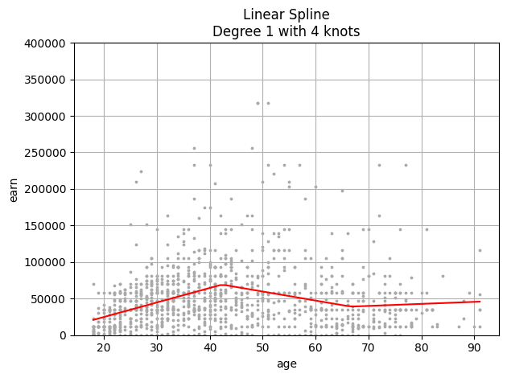

```python
sorted_index = np.argsort(train['age'])
age_sorted  = train['age'].iloc[sorted_index]
pred_linear_spline_sorted = pd.Series(pred_linear_spline).iloc[sorted_index]
plt.scatter(train.age, train.earn, s = 3, color = 'darkgray')
plt.plot(age_sorted, pred_linear_spline_sorted,  color = 'red')
plt.xlabel('age')
plt.ylabel('earn')
plt.ylim(0,4e5)
plt.title('Linear Spline\nDegree 1 with 4 knots')
#plt.legend()
plt.grid()
plt.tight_layout()
plt.show()
```

```python
cubic_spline = SplineTransformer(degree = 2,  n_knots = 4, include_bias=False)
X_train = train.loc[:,['age']]  # to generate a dataframe. train.age will create a pandas series
y_train = train.earn
X_train = cubic_spline.fit_transform(X_train)
reg_cubic_spline = LinearRegression()
reg_cubic_spline.fit(X_train, y_train)
pred_cubic_spline = reg_cubic_spline.predict(X_train)
```

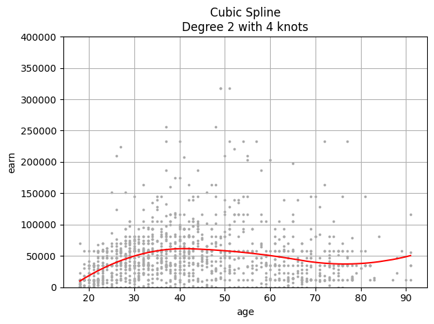

```python
sorted_index = np.argsort(train['age'])
age_sorted  = train['age'].iloc[sorted_index]
pred_cubic_spline_sorted = pd.Series(pred_cubic_spline).iloc[sorted_index]
plt.scatter(train.age, train.earn, s = 3, color = 'darkgray')
plt.plot(age_sorted, pred_cubic_spline_sorted,  color = 'red')
plt.xlabel('age')
plt.ylabel('earn')
plt.ylim(0,4e5)
plt.title('Cubic Spline\nDegree 2 with 4 knots')
#plt.legend()
plt.grid()
plt.tight_layout()
plt.show()
```

Expanding Cubic Spline to cover all features. Categorical variables were dummy coded and then separated from the numeric variables.

```python
cubic_spline = SplineTransformer(degree = 2, n_knots = 4, include_bias=False)
X_dummies = pd.get_dummies(train.drop(['earn'], axis = 1), columns = ['gender','ethnicity','smokenow'], drop_first=True)
y_train = train.earn
cubic_spline.fit(X_dummies.iloc[:,0:7])
X_train = cubic_spline.transform(X_dummies.iloc[:,0:7])     # cubic spline for non-dummies
X_train.shape
```

```
(1250, 28)
```

```python
X_train = np.hstack((X_train, X_dummies.iloc[:,7:12]))      # combine splines with dummies
X_train.shape
```

```
(1250, 33)
```

```python
reg_cubic_spline = LinearRegression()
reg_cubic_spline.fit(X_train, y_train)
pred_cubic_spline = reg_cubic_spline.predict(X_train)
root_mean_squared_error(y_train, pred_cubic_spline)
```

```
45294.28302882289
```

```python
X_dummies_test = pd.get_dummies(test.drop(['earn'], axis = 1), columns = ['gender','ethnicity','smokenow'], drop_first=True)
y_test = test.earn
X_test = cubic_spline.transform(X_dummies_test.iloc[:,0:7]) # cubic spline for non-dummies
X_test = np.hstack((X_test, X_dummies_test.iloc[:,7:12]))      # combine splines with dummies
pred_cubic_spline_test = reg_cubic_spline.predict(X_test)
root_mean_squared_error(y_test, pred_cubic_spline_test)
```

```
46101.570060762555
```

## Generalized Additive Models

- Allows for flexible nonlinearities in several variables, but retains the additive structure of linear models
- Can include a mix of linear and non-linear terms
- GAMs are additive. However, low-order interactions can be included.
- GAMs can be used for classification in the same way as for linear regression

### pygam

```python
from pygam import s, l, f, LinearGAM, LogisticGAM
```

pygam relies on deprecated functions and objects from numpy and scipy. Until a new version of pygam is introduced, the following monkey patch will address the issue.

```python
import numpy as np
np.int = int
import scipy.sparse as sp
# give sparse matrix a .A alias to toarray()
for cls in (sp.csr_matrix, sp.csc_matrix, sp.bsr_matrix, sp.dia_matrix):
    setattr(cls, 'A', property(lambda self: self.toarray()))
```

### GAM with one variable

Here, we begin by fitting a GAM with just age. Unlike statsmodels, pygam does not accomodate feature names. Also, pygam only works with numpy arrays.

Age is set to be a smoothing spline, indicated by s(0).

```python
gam = LinearGAM(s(0))
X_train = train.loc[:,['age']]
gam.fit(X_train.values, train.earn.values)
#gam.predict(X_train)
gam.summary()
```

```
LinearGAM
=============================================== ==========================================================
Distribution:                        NormalDist Effective DoF:                                     14.2225
Link Function:                     IdentityLink Log Likelihood:                                -28232.0278
Number of Samples:                         1250 AIC:                                            56494.5006
                                                AICc:                                           56494.9009
                                                GCV:                                       2622398951.8968
                                                Scale:                                     2568745983.2242
                                                Pseudo R-Squared:                                   0.0757
==========================================================================================================
Feature Function                  Lambda               Rank         EDoF         P > x        Sig. Code
================================= ==================== ============ ============ ============ ============
s(0)                              [0.6]                20           14.2         3.33e-14     ***
intercept                                              1            0.0          1.11e-16     ***
==========================================================================================================
Significance codes:  0 '***' 0.001 '**' 0.01 '*' 0.05 '.' 0.1 ' ' 1

WARNING: Fitting splines and a linear function to a feature introduces a model identifiability problem
         which can cause p-values to appear significant when they are not.

WARNING: p-values calculated in this manner behave correctly for un-penalized models or models with
         known smoothing parameters, but when smoothing parameters have been estimated, the p-values
         are typically lower than they should be, meaning that the tests reject the null too readily.
```

### GAM with multiple variables

```python
X_train = pd.get_dummies(train.drop(['earn'], axis = 1),
                         columns = ['gender','ethnicity','smokenow'],
                         drop_first=True)
X_dummies
```

|  | age | height | weight | education | walk | exercise | tense | gender_male | ethnicity_Asian | ethnicity_Hispanic | ethnicity_White | smokenow_2 |
| --- | --- | --- | --- | --- | --- | --- | --- | --- | --- | --- | --- | --- |
| 1042 | 24 | 73 | 165 | 12 | 7 | 7 | 1 | True | False | False | True | True |
| 886 | 43 | 66 | 151 | 16 | 5 | 2 | 0 | False | False | False | True | True |
| 1039 | 38 | 64 | 125 | 12 | 8 | 2 | 1 | False | False | False | True | True |
| 1239 | 81 | 66 | 140 | 12 | 1 | 1 | 0 | False | False | False | True | True |
| 437 | 42 | 74 | 195 | 12 | 8 | 2 | 7 | True | False | False | True | True |
| ... | ... | ... | ... | ... | ... | ... | ... | ... | ... | ... | ... | ... |
| 298 | 35 | 66 | 112 | 18 | 5 | 2 | 0 | False | True | False | False | True |
| 948 | 31 | 72 | 150 | 11 | 7 | 5 | 0 | True | False | False | True | False |
| 420 | 55 | 64 | 150 | 12 | 7 | 1 | 0 | False | False | False | True | True |
| 326 | 44 | 64 | 135 | 13 | 8 | 2 | 0 | False | False | False | True | False |
| 1692 | 28 | 64 | 140 | 17 | 4 | 6 | 0 | False | False | False | True | True |

1250 rows × 12 columns

Next, in the GAM, we fit a spline for the numeric variables and a factor term for the dummy variables.

```python
gam = LinearGAM(s(0) + s(1) + s(2) + s(3) + s(4) + s(5) + s(6) + f(7) + f(8) + f(9) + f(10) + f(11))
gam.fit(X_train.values, train.earn.values)
gam.summary()
```

```
LinearGAM
=============================================== ==========================================================
Distribution:                        NormalDist Effective DoF:                                      73.336
Link Function:                     IdentityLink Log Likelihood:                                -27924.6242
Number of Samples:                         1250 AIC:                                            55997.9205
                                                AICc:                                           56007.4554
                                                GCV:                                       2244421070.6744
                                                Scale:                                     2008714543.9871
                                                Pseudo R-Squared:                                   0.3118
==========================================================================================================
Feature Function                  Lambda               Rank         EDoF         P > x        Sig. Code
================================= ==================== ============ ============ ============ ============
s(0)                              [0.6]                20           14.6         2.21e-10     ***
s(1)                              [0.6]                20           11.6         9.07e-02     .
s(2)                              [0.6]                20           11.9         9.06e-01
s(3)                              [0.6]                20           11.0         2.55e-14     ***
s(4)                              [0.6]                20           7.0          5.64e-01
s(5)                              [0.6]                20           5.9          4.96e-01
s(6)                              [0.6]                20           6.7          1.57e-09     ***
f(7)                              [0.6]                2            1.0          9.09e-09     ***
f(8)                              [0.6]                2            0.9          5.50e-01
f(9)                              [0.6]                2            0.9          7.65e-01
f(10)                             [0.6]                2            0.9          5.35e-01
f(11)                             [0.6]                2            0.9          6.72e-01
intercept                                              1            0.0          2.14e-05     ***
==========================================================================================================
Significance codes:  0 '***' 0.001 '**' 0.01 '*' 0.05 '.' 0.1 ' ' 1

WARNING: Fitting splines and a linear function to a feature introduces a model identifiability problem
         which can cause p-values to appear significant when they are not.

WARNING: p-values calculated in this manner behave correctly for un-penalized models or models with
         known smoothing parameters, but when smoothing parameters have been estimated, the p-values
         are typically lower than they should be, meaning that the tests reject the null too readily.
```

```python
pred_gam = gam.predict(X_train)
root_mean_squared_error(y_train, pred_gam)
```

```
43484.08447374743
```

```python
X_test = pd.get_dummies(test.drop(['earn'], axis = 1),
                        columns = ['gender','ethnicity','smokenow'],
                        drop_first=True)
pred_gam_test = gam.predict(X_test)
root_mean_squared_error(y_test, pred_gam_test)
```

```
48390.037413790174
```

### Partial Dependence Plots

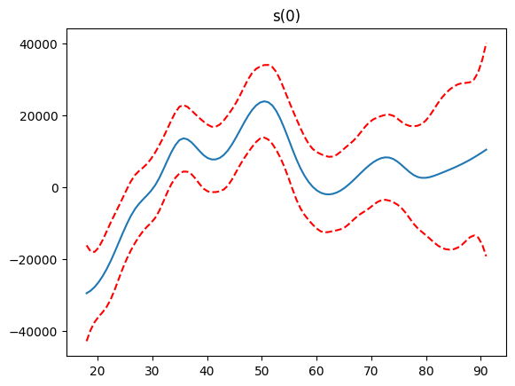

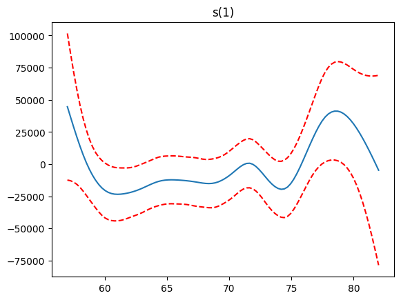

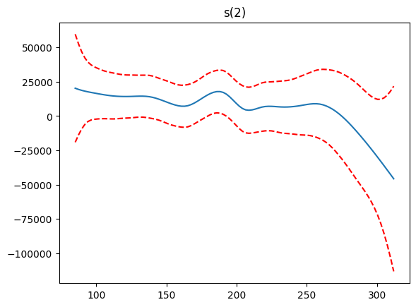

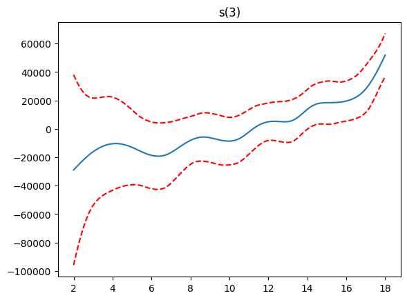

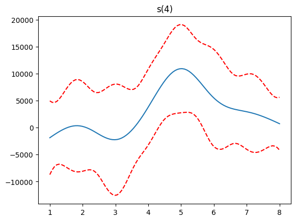

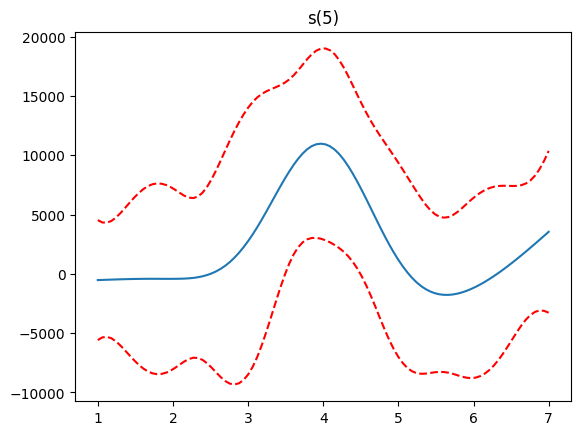

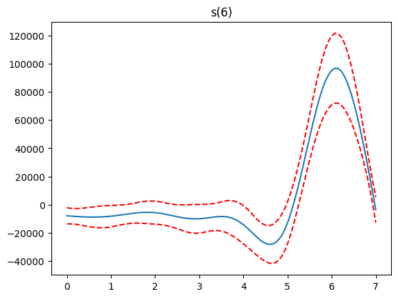

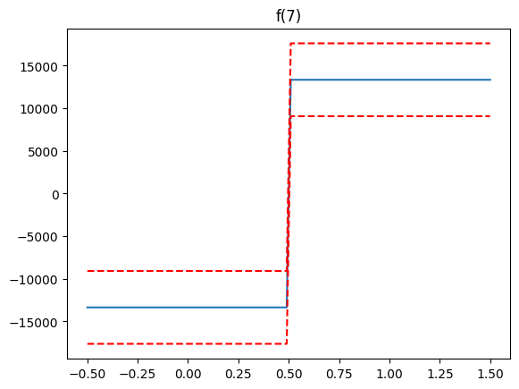

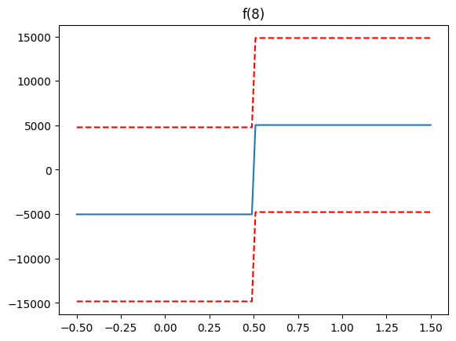

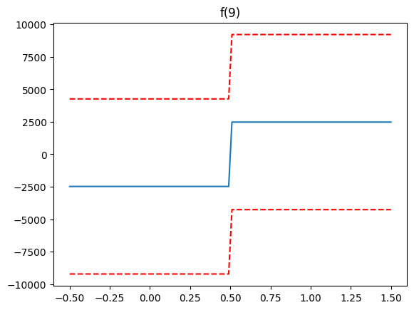

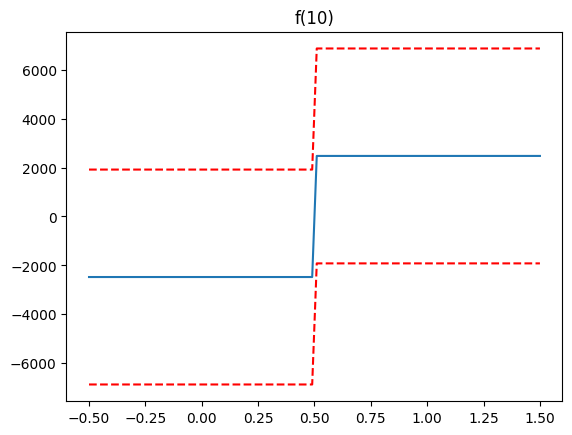

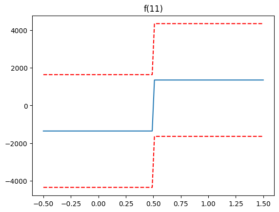

```python
for i, term in enumerate(gam.terms):
    if term.isintercept:
        continue

    XX = gam.generate_X_grid(term=i)
    pdep, confi = gam.partial_dependence(term=i, X=XX, width=0.95)

    plt.figure()
    plt.plot(XX[:, term.feature], pdep)
    plt.plot(XX[:, term.feature], confi, c='r', ls='--')
    plt.title(repr(term))
    plt.show()
```

### GAM with tuned Lambda

GAM was fit using a default value of lambda. Next, we will tune lambda for all terms. Tuning lambda for each term will improve model performance but it can take a very long time to run.

```python
np.logspace(-4,5,num = 20)
```

```
array([1.00000000e-04, 2.97635144e-04, 8.85866790e-04, 2.63665090e-03,
       7.84759970e-03, 2.33572147e-02, 6.95192796e-02, 2.06913808e-01,
       6.15848211e-01, 1.83298071e+00, 5.45559478e+00, 1.62377674e+01,
       4.83293024e+01, 1.43844989e+02, 4.28133240e+02, 1.27427499e+03,
       3.79269019e+03, 1.12883789e+04, 3.35981829e+04, 1.00000000e+05])
```

```python
%%time
gam = LinearGAM(s(0) + s(1) + s(2) + s(3) + s(4) + s(5) + s(6) + f(7) + f(8) + f(9) + f(10))
import numpy as np
lam = np.logspace(-5,5,100)
gam.gridsearch(X_train.values, train.earn.values, lam=lam)
#gam.summary()
```

```
100% (100 of 100) |######################| Elapsed Time: 0:00:20 Time:  0:00:200001
```

```
CPU times: total: 25 s
Wall time: 20 s
```

```
LinearGAM(callbacks=[Deviance(), Diffs()], fit_intercept=True,
   max_iter=100, scale=None,
   terms=s(0) + s(1) + s(2) + s(3) + s(4) + s(5) + s(6) + f(7) + f(8) + f(9) + f(10) + intercept,
   tol=0.0001, verbose=False)
```

```python
gam.lam
```

```
[[np.float64(14.508287784959402)],
 [np.float64(14.508287784959402)],
 [np.float64(14.508287784959402)],
 [np.float64(14.508287784959402)],
 [np.float64(14.508287784959402)],
 [np.float64(14.508287784959402)],
 [np.float64(14.508287784959402)],
 [np.float64(14.508287784959402)],
 [np.float64(14.508287784959402)],
 [np.float64(14.508287784959402)],
 [np.float64(14.508287784959402)]]
```

```python
gam.fit(X_train, train.earn)
pred_gam = gam.predict(X_train)
root_mean_squared_error(y_train, pred_gam)
```

```
44127.6709917691
```

```python
gam.fit(X_test, test.earn)
pred_gam_test = gam.predict(X_test)
root_mean_squared_error(y_test, pred_gam_test)
```

```
43643.48404200955
```

### Partial Dependence Plots

Source: https://pygam.readthedocs.io/en/latest/notebooks/quick_start.html

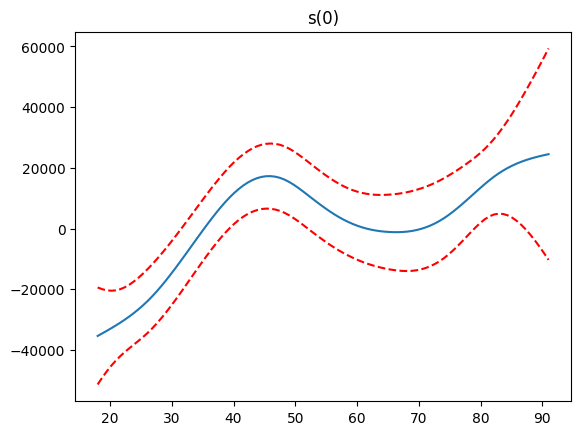

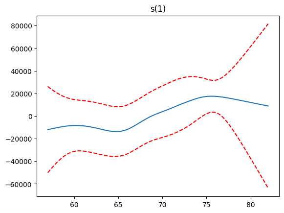

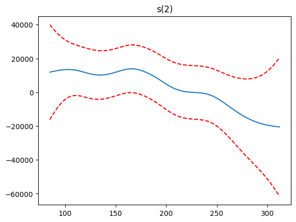

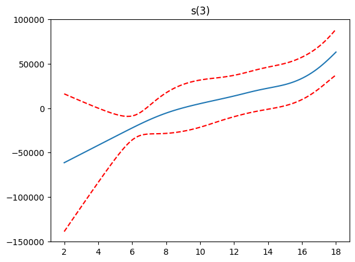

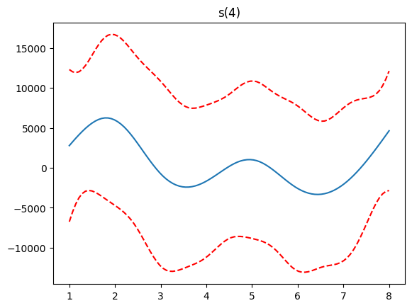

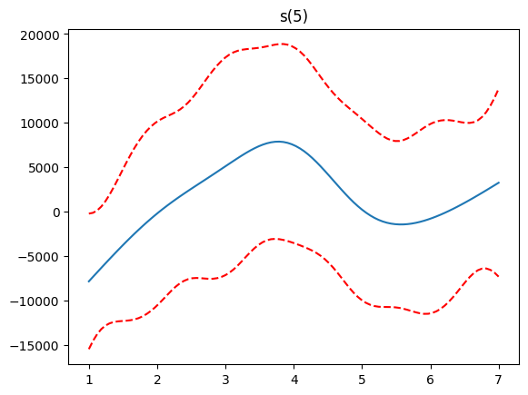

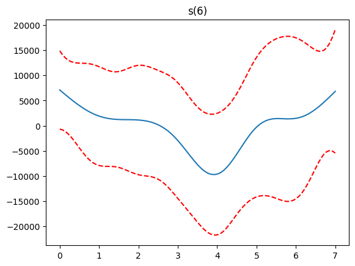

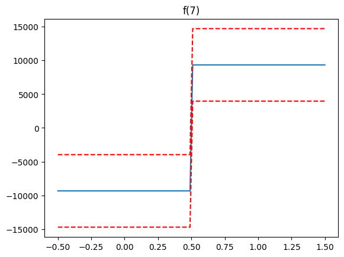

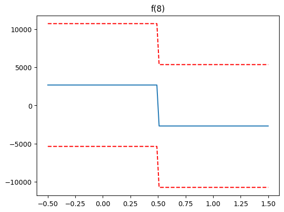

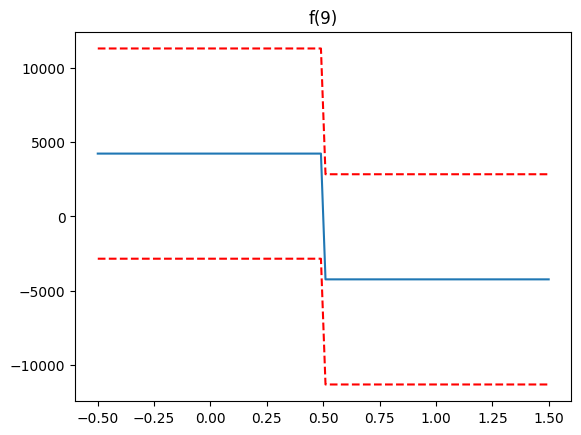

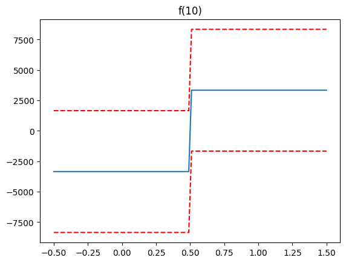

```python
for i, term in enumerate(gam.terms):
    if term.isintercept:
        continue

    XX = gam.generate_X_grid(term=i)
    pdep, confi = gam.partial_dependence(term=i, X=XX, width=0.95)

    plt.figure()
    plt.plot(XX[:, term.feature], pdep)
    plt.plot(XX[:, term.feature], confi, c='r', ls='--')
    plt.title(repr(term))
    plt.show()
```

## Summary

In this note we examined nonlinear regression methods including

- polynomial regression
- splines
- generalized additive models

This file was generated using Python 3.13.5 on Windows 10 with the following libraries: matplotlib 3.10.3, numpy 2.3.1, pandas 2.3.0, pygam 0.10.1, scikit-learn 1.7.1, scipy 1.16.0, statsmodels 0.14.5